# AB programación: Dataset de estudiantes

## Análisis de horas dormidas

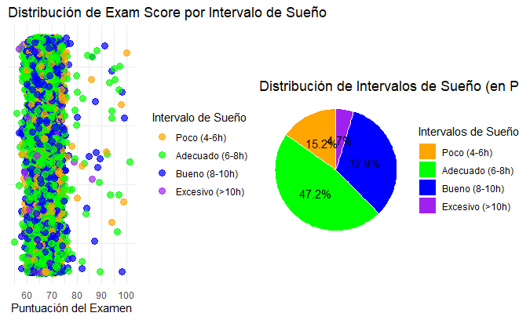

```r
st_clean <- st_clean %>%
  mutate(Sleep_Interval = cut(Sleep_Hours,
                              breaks = c(0, 4, 6, 8, 10, Inf),
                              labels = c("Muy poco (<4h)", "Poco (4-6h)", "Adecuado (6-8h)", "Bueno (8-10h)", "Excesivo (>10h)"),
                              right = FALSE))

sleep_intervals <- st_clean %>%
  group_by(Sleep_Interval) %>%
  summarise(Count = n()) %>%
  mutate(Percentage = Count / sum(Count) * 100)

grafico_dispersion <- ggplot(st_clean, aes(x = Exam_Score, y = 1, color = Sleep_Interval)) +
  geom_jitter(height = 0.1, width = 0.3, size = 3, alpha = 0.7) +
  scale_color_manual(values = c("Muy poco (<4h)" = "red",
                                "Poco (4-6h)" = "orange",
                                "Adecuado (6-8h)" = "green",
                                "Bueno (8-10h)" = "blue",
                                "Excesivo (>10h)" = "purple")) +
  theme_minimal() +
  labs(title = "Distribución de Exam Score por Intervalo de Sueño",
       x = "Puntuación del Examen",
       y = "",
       color = "Intervalo de Sueño") +
  theme(axis.text.y = element_blank(),
        axis.ticks.y = element_blank(),
        axis.title.y = element_blank(),
        panel.grid.major.y = element_blank())

grafico_circular <- ggplot(sleep_intervals, aes(x = "", y = Percentage, fill = Sleep_Interval)) +
  geom_bar(stat = "identity", width = 1, color = "white") +
  coord_polar(theta = "y") +
  scale_fill_manual(values = c("Muy poco (<4h)" = "red",
                               "Poco (4-6h)" = "orange",
                               "Adecuado (6-8h)" = "green",
                               "Bueno (8-10h)" = "blue",
                               "Excesivo (>10h)" = "purple")) +
  theme_void() +
  labs(title = "Distribución de Intervalos de Sueño (en Porcentaje)",
       fill = "Intervalos de Sueño") +
  geom_text(aes(label = sprintf("%.1f%%", Percentage)),
            position = position_stack(vjust = 0.5), size = 4)


grid.arrange(grafico_dispersion, grafico_circular, nrow = 1, ncol = 2)
```

```r
NA
NA
```

No parece existir ningún tipo de correlación entre las horas de sueño con las notas del examen.

## Conclusión de los análisis de los gráficos

Tras el análisis de varios factores desde múltiples perspectivas, los resultados que se obtuvieron en las todas las comparaciones fueron consistentes. Esto nos sugiere que las variables evaluadas no tienen un impacto significativo en el desempeño de los estudiantes, o bien el dataset ha sido diseñado de manera que solo una pocas variables, específicamente las 3/4 columnas numéricas que luego especificaremos, poseen una influencia real en los resultados.

## Análisis de las 4 correlaciones mayores

Si observamos los resultados del mapa de correlaciones nos da que hay 4 variables numéricas que tienen una relación significativa con la variable a predecir.

variables predictivas serán:

- `Hours_Studied`
- `Previous_Scores`
- `Attendance`
- `Tutoring_Sessions`

y la variable a predecir será: `Exam_Score.`

Analicemos visualmente la distribución de estas 4 variables.

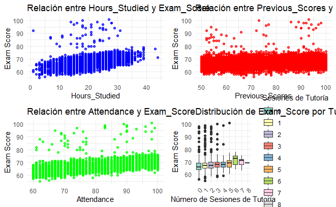

```r
var1 <- "Hours_Studied"
var2 <- "Previous_Scores"
var3 <- "Attendance"
var4 <- "Tutoring_Sessions"

grafico_var1 <- ggplot(st_clean, aes_string(x = var1, y = "Exam_Score")) +
  geom_point(alpha = 0.7, color = "blue") +
  theme_minimal() +
  labs(title = paste("Relación entre", var1, "y Exam_Score"),
       x = var1,
       y = "Exam Score")

grafico_var2 <- ggplot(st_clean, aes_string(x = var2, y = "Exam_Score")) +
  geom_point(alpha = 0.7, color = "red") +
  theme_minimal() +
  labs(title = paste("Relación entre", var2, "y Exam_Score"),
       x = var2,
       y = "Exam Score")

grafico_var3 <- ggplot(st_clean, aes_string(x = var3, y = "Exam_Score")) +
  geom_point(alpha = 0.7, color = "green") +
  theme_minimal() +
  labs(title = paste("Relación entre", var3, "y Exam_Score"),
       x = var3,
       y = "Exam Score")

grafico_var4 <- ggplot(st_clean, aes(x = as.factor(Tutoring_Sessions), y = Exam_Score, fill = as.factor(Tutoring_Sessions))) +
  geom_boxplot() +
  theme_minimal() +
  scale_fill_brewer(palette = "Set3") +
  labs(title = paste("Distribución de Exam_Score por", var4),
       x = "Número de Sesiones de Tutoría",
       y = "Exam Score",
       fill = "Sesiones de Tutoría") +
  theme(axis.text.x = element_text(angle = 45, hjust = 1))


grid.arrange(grafico_var1, grafico_var2, grafico_var3, grafico_var4, nrow = 2, ncol = 2)
```

```r
NA
NA
```

Se observa que la distribución de los datos sigue una tendencia lineal en la mayoría de los casos, lo que sugiere una posible relación proporcional entre las variables analizadas. Para evaluar con mayor precisión el grado de ajuste de esta relación, sera necesario incorporar una línea de regresión que permita visualizar cómo se alinean los datos con respecto a una tendencia esperada.

### Añadimos la recta de regresión

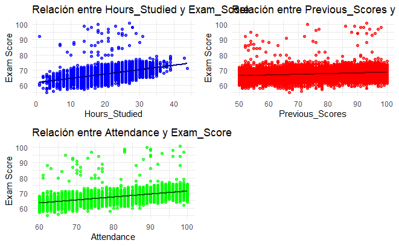

```r
var1 <- "Hours_Studied"
var2 <- "Previous_Scores"
var3 <- "Attendance"

grafico_var1 <- ggplot(st_clean, aes_string(x = var1, y = "Exam_Score")) +
  geom_point(alpha = 0.7, color = "blue") +
  geom_smooth(method = "lm", se = FALSE, color = "darkblue") +
  theme_minimal() +
  labs(title = paste("Relación entre", var1, "y Exam_Score"),
       x = var1,
       y = "Exam Score")

grafico_var2 <- ggplot(st_clean, aes_string(x = var2, y = "Exam_Score")) +
  geom_point(alpha = 0.7, color = "red") +
  geom_smooth(method = "lm", se = FALSE, color = "darkred") +
  theme_minimal() +
  labs(title = paste("Relación entre", var2, "y Exam_Score"),
       x = var2,
       y = "Exam Score")

grafico_var3 <- ggplot(st_clean, aes_string(x = var3, y = "Exam_Score")) +
  geom_point(alpha = 0.7, color = "green") +
  geom_smooth(method = "lm", se = FALSE, color = "darkgreen") +
  theme_minimal() +
  labs(title = paste("Relación entre", var3, "y Exam_Score"),
       x = var3,
       y = "Exam Score")

grid.arrange(grafico_var1, grafico_var2, grafico_var3, nrow = 2, ncol = 2)
```

Como podemos comprobar viendo la recta de regresión y el mapa de puntos como nos indicaba el mapa de correlación estos son los 3 valores que mas influyen en la nota del examen.